# Speakers Classification

Project

Solve a classification problem: Classify the speakers of given features.

Author

Wu Hao

Published

2025/1/9

## Global Settings

We import all the packages here to make us easier to call.

```python
# Numerical Operations
import numpy as np
import math
import random

# Pytorch
import torch
from torch.utils.data import DataLoader, Dataset, random_split
import torch.nn.functional as F
from torch.nn.utils.rnn import pad_sequence
import torch.nn as nn
from torch.optim import Optimizer
from torch.optim.lr_scheduler import LambdaLR

# For plotting learning curve
from torch.utils.tensorboard import SummaryWriter

# Reading/Writing Data
import scipy.io as scio
import os
import csv
import pandas as pd

# Directory Operation
from collections import Counter
import json

# Regular Expressions
import re

# Training Process
import sys
import time

# Showing Results
from IPython.display import display
from IPython.display import Image

# training optimization
import gc
```

For the reproducibility of the experiment, we fix the random number generator seeds here.

```python
#Fixes random number generator seeds for reproducibility.
def same_seed(seed):
    np.random.seed(seed)
    random.seed(seed)
    torch.manual_seed(seed)
    if torch.cuda.is_available():
        torch.cuda.manual_seed(seed)
        torch.cuda.manual_seed_all(seed)
    torch.backends.cudnn.benchmark = False
    torch.backends.cudnn.deterministic = True
```

## Configurations

```python
device = 'cuda' if torch.cuda.is_available() else 'cpu'
config = {
    'seed': 342425,       # seed number, we can pick lucky number. :)
    'valid_ratio': 0.8,   # validation_size = train_size * valid_ratio
    'n_steps': 100000,     # Number of steps.
    'batch_size': 32,
    'learning_rate': 1e-3,
    'warmup_steps': 1000,
    'save_steps': 10000,
    'valid_steps': 2000,
    'early_stop': 15000,    # If model has not improved for this many consecutive epochs, stop training.
    'n_workers': 0,
    'save_path': './Voxceleb2/model.ckpt'  # our model will be saved here.
}
```

## Datasets

We can download data in [here](https://www.kaggle.com/competitions/ml2023springhw4)

### Dataset Description:

Original dataset is [Voxceleb2](https://www.robots.ox.ac.uk/~vgg/data/voxceleb/vox2.html), and we randomly select 600 speakers from Voxceleb2. Then preprocess the raw waveforms into mel-spectrograms.

### The architecture of data directory:

data directory |—- metadata.json |—- testdata.json |—- mapping.json |—- uttr-{random string}.pt

```python
# show the composition of data_file.
def count_files_in_directory(directory):
    file_count = Counter()

    # Regular Expressions
    json_files_pattern = re.compile(r'.*\.json$')  #match .json
    uttr_files_pattern = re.compile(r'.*\.pt$')  # match uttr-{random string}.pt

    for root, _, files in os.walk(directory):
        for file in files:
            file_path = os.path.join(root, file)

            if json_files_pattern.match(file):
                file_count[".json"] += 1
            elif uttr_files_pattern.match(file):
                file_count[".pt"] += 1

    return file_count

data_dir = './Voxceleb2/Voxceleb2_Dataset'
file_counts = count_files_in_directory(data_dir)

for file_type, count in file_counts.items():
    print(f"{file_type}: {count}")
```

```
.pt: 64669
.json: 3
```

### The information in metadata

1. “n_mels”: The dimention of mel-spectrogram.
2. “speakers”: A dictionary. Key: speaker ids. Value: “feature_path” and “mel_len”

## Training Code

### Dataset Processing

We should construct the train_data, valid_data and test_data.

First, we extract the information of speaker from `metadata.json` and `uttr-{random string}.pt`, and produce our dataset.

Let’s show an example in `metadata.json` that can give us clues.

```json
{
"speakers": {
        "id03074": [
            {
                "feature_path": "uttr-18e375195dc146fd8d14b8a322c29b90.pt",
                "mel_len": 435
            },
            {
                "feature_path": "uttr-fe3576f81b5841ab8931c1dd611bf547.pt",
                "mel_len": 344
            },
        ]
    }
}
```

We can get the speaker name and the corresponding feature path. And we also have a `mapping.json` that can help us map from speaker name to their corresponding id.

```python
def create_data(data_dir):
    # Load the mapping from speaker name to their corresponding id.
    mapping_path = os.path.join(data_dir, 'mapping.json')
    mapping = json.load(open(mapping_path))
    speaker2id = mapping["speaker2id"]

    # Load metadata of training data.
    metadata_path = os.path.join(data_dir, 'metadata.json')
    metadata = json.load(open(metadata_path))["speakers"] # dictionary {name: }

    speaker_num = len(metadata.keys()) #key: speaker name
    speaker_data =[]
    for speaker in metadata.keys():
        for utterances in metadata[speaker]:
            speaker_data.append([utterances["feature_path"], speaker2id[speaker]])
    return speaker_num, speaker_data
```

But a new problem has arisen: from the `metadata.json`, we find that the length of the segment is not the same. We should unify the length.

```python
def adjust_frames(data_dir, feat_path, speaker, segment_len=128):
    if speaker is not None:
        segment = torch.load(os.path.join(data_dir, feat_path), weights_only=True)
        # Segmemt mel-spectrogram into "segment_len" frames.
        if len(segment) > segment_len:
         # Randomly get the starting point of the segment.
            start = random.randint(0, len(segment) - segment_len)
        # Get a segment with "segment_len" frames.
            segment = torch.FloatTensor(segment[start:start+segment_len])
        else:
            segment = torch.FloatTensor(segment)
    # Turn the speaker id into long for computing loss later.
        speaker = torch.FloatTensor([speaker]).long()
        return segment, speaker
```

Now, we extracted the information about the speaker successfully and unified the length of each audio.

It’s time to construct train_dataset, valid_dataset and test_dataset.

As usual, let’s start by splitting the data.

```python
def data_split(data_set, ratio, seed):
    split_1_size = int(ratio * len(data_set))
    split_2_size = len(data_set) - split_1_size
    split_2_set, split_1_set = random_split(data_set, [split_2_size, split_1_size], generator=torch.Generator().manual_seed(seed))
    #Proportionally divide split1, the rest is split2
    return split_1_set, split_2_set
```

So, we’ve got:

1. train_features_paths, train_labels (id)
2. valid_features_paths, valid_labels (id)
3. test_features_paths

Now, it’s time to construct our dataset.

```python
class myDataset(Dataset):
    def __init__(self, data_dir, segment_len=128):
        self.data_dir = data_dir
        self.segment_len = segment_len
        self.speaker_num, self.speaker_data = create_data(data_dir)


    def __getitem__(self, index):
        feat_path, speaker = self.speaker_data[index]
        X, Y = adjust_frames(data_dir, feat_path, speaker)
        return X, Y

    def __len__(self):
        return len(self.speaker_data)

    def get_speaker_number(self):
        return self.speaker_num

data_set = myDataset(data_dir)
speaker_num = data_set.get_speaker_number()
```

```python
def collate_batch(batch):
    # Process features within a batch.
    """Collate a batch of data."""
    mel, speaker = zip(*batch)
    # Because we train the model batch by batch, we need to pad the features in the same batch to make their lengths the same.
    mel = pad_sequence(mel, batch_first=True, padding_value=-20)    # pad log 10^(-20) which is very small value.
    # mel: (batch size, length, 40)
    return mel, torch.FloatTensor(speaker).long()

def inference_collate_batch(batch):
    """Collate a batch of data."""
    feat_paths, mels = zip(*batch)

    return feat_paths, torch.stack(mels)

train_dataset, valid_dataset = data_split(data_set, config['valid_ratio'], config['seed'])

print(f"Shape of train_data is {len(train_dataset)}")
print(f"Shape of test_data is {len(valid_dataset)}")

train_loader = DataLoader(
        train_dataset,
        batch_size=config['batch_size'],
        shuffle=True,
        drop_last=True,
        num_workers=config['n_workers'],
        pin_memory=True,
        collate_fn=collate_batch,
    )
valid_loader = DataLoader(
        valid_dataset,
        batch_size=config['batch_size'],
        num_workers=config['n_workers'],
        drop_last=True,
        pin_memory=True,
        collate_fn=collate_batch,
    )
```

```
Shape of train_data is 45332
Shape of test_data is 11334
```

At this point, we’ve finished building the dataset. With train_loader, we can get bulk data during the training process and pass it to the model. It’s time to construct our model.

### Model

We adopt the base transformer encoder layer in [Attention Is All You Need](https://arxiv.org/abs/1706.03762) as our model.

```python
class Classifier(nn.Module):
    def __init__(self, d_model=80, n_spks=600, dropout=0.1):
        super().__init__()
        # Project the dimension of features from that of input into d_model.
        self.prenet = nn.Linear(40, d_model)
        self.encoder_layer = nn.TransformerEncoderLayer(
            d_model=d_model, dim_feedforward=256, nhead=2
        )
        # self.encoder = nn.TransformerEncoder(self.encoder_layer, num_layers=2)

        # Project the the dimension of features from d_model into speaker nums.
        self.pred_layer = nn.Sequential(
            nn.Linear(d_model, d_model),
            nn.ReLU(),
            nn.Linear(d_model, n_spks),
        )

    def forward(self, mels):
        """
        args:
            mels: (batch size, length, 40)
        return:
            out: (batch size, n_spks)
        """
        # out: (batch size, length, d_model)
        out = self.prenet(mels)
        # out: (length, batch size, d_model)
        out = out.permute(1, 0, 2)
        # The encoder layer expect features in the shape of (length, batch size, d_model).
        out = self.encoder_layer(out)
        # out: (batch size, length, d_model)
        out = out.transpose(0, 1)
        # mean pooling
        stats = out.mean(dim=1)

        # out: (batch, n_spks)
        out = self.pred_layer(stats)
        return out
```

For transformer architecture, the design of learning rate schedule is different from that of CNN. Previous works show that the warmup of learning rate is useful for training models with transformer architectures.

This training method combines the warmup and cosine decay strategies. Specifically, the learning rate gradually increases at the beginning of training, then gradually decays and finally tends to zero.

```python
def get_cosine_schedule_with_warmup(
    optimizer: Optimizer,
    num_warmup_steps: int,
    num_training_steps: int,
    num_cycles: float = 0.5,
    last_epoch: int = -1,
):
    def lr_lambda(current_step):
        # Warmup
        if current_step < num_warmup_steps:
            return float(current_step) / float(max(1, num_warmup_steps))
        # decadence
        progress = float(current_step - num_warmup_steps) / float(
            max(1, num_training_steps - num_warmup_steps)
        )
        return max(
            0.0, 0.5 * (1.0 + math.cos(math.pi * float(num_cycles) * 2.0 * progress))
        )
    return LambdaLR(optimizer, lr_lambda, last_epoch)
```

### Training Loop

```python
def trainer(train_loader, valid_loader, model, config, device):

    criterion = nn.CrossEntropyLoss()  # loss: CrossEntropyLoss
    #optimization algorithm (Adam).
    optimizer = torch.optim.AdamW(model.parameters(), lr=config['learning_rate'])
    train_iterator = iter(train_loader)
    print(f"[Info]: Finish loading data!",flush = True)

    writer = SummaryWriter() # Writer of tensorboard.

    n_steps, best_acc, step, early_stop_count, epoch_start_time = config['n_steps'], 0.0, 0, 0, 0
    scheduler = get_cosine_schedule_with_warmup(optimizer, config['warmup_steps'], n_steps)

    for step in range(n_steps):
        # Get data
        try:
            batch = next(train_iterator)
        except StopIteration:
            train_iterator = iter(train_loader)
            batch = next(train_iterator)

        train_acc = 0.0
        segment, speaker = batch
        segment, speaker = segment.to(device), speaker.to(device)   # Move our data to device.
        train_pred = model(segment)
        loss = criterion(train_pred, speaker)
        train_acc = torch.mean((train_pred.argmax(1) == speaker).float())

        train_batch_loss = loss.detach().item()
        train_acc = train_acc.detach().item()

        # update model
        loss.backward()                     # Compute gradient(back propagation).
        optimizer.step()                    # Update parameters (after back propagation).
        scheduler.step()
        optimizer.zero_grad()               # Set gradient to zero.

        writer.add_scalar('Loss/train', train_batch_loss, step)
        writer.add_scalar('Accuracy/train', train_acc, step)

        if (step+1) % config['valid_steps'] == 0:
        #As step reaches valid_steps, change to valid mode
            model.eval() # Set our model to evaluation mode.
            valid_acc = 0.0
            loss_record = []

            for segment, speaker in valid_loader:
                with torch.no_grad():
                    segment, speaker = segment.to(device), speaker.to(device)
                    valid_pred = model(segment)
                    batch_loss = criterion(valid_pred, speaker)
                    valid_acc += np.sum(np.argmax(valid_pred.detach().cpu().numpy(), axis=1) == speaker.cpu().numpy())
                    loss_record.append(batch_loss.item())

            mean_valid_loss = sum(loss_record)/len(loss_record)
            valid_acc = valid_acc / valid_dataset.__len__()

            print('[%03d/%03d] %2.2f sec(s) Train Acc: %3.6f Loss: %3.6f | Val Acc: %3.6f loss: %3.6f' % \
              (step + 1, n_steps, time.time() - epoch_start_time, \
               train_acc, train_batch_loss, valid_acc,
               mean_valid_loss))
            epoch_start_time = time.time()
            writer.add_scalar('Loss/valid', mean_valid_loss, step)
            writer.add_scalar('Accuracy/valid', valid_acc, step)

            if valid_acc > best_acc:
                best_acc = valid_acc
                torch.save(model.state_dict(), config['save_path']) # Save our best model
                print('Saving model with accuracy {:.3f}...'.format(best_acc))
                early_stop_count = 0
            else:
                early_stop_count += 2000

            if early_stop_count >= config['early_stop']:
                print('\nModel is not improving, so we halt the training session.')
                return
```

```python
model = Classifier(n_spks=speaker_num).to(device)
print(f"[Info]: Finish creating model!",flush = True)
trainer(train_loader, valid_loader, model, config, device)
```

```
[Info]: Finish creating model!
[Info]: Finish loading data!
[2000/100000] 1736785147.36 sec(s) Train Acc: 0.062500 Loss: 4.763556 | Val Acc: 0.139668 loss: 4.180274
Saving model with accuracy 0.140...
[4000/100000] 29.40 sec(s) Train Acc: 0.375000 Loss: 3.558872 | Val Acc: 0.253662 loss: 3.497505
Saving model with accuracy 0.254...
[6000/100000] 30.30 sec(s) Train Acc: 0.375000 Loss: 3.103851 | Val Acc: 0.318246 loss: 3.122223
Saving model with accuracy 0.318...
[8000/100000] 30.00 sec(s) Train Acc: 0.343750 Loss: 2.995615 | Val Acc: 0.348421 loss: 2.937050
Saving model with accuracy 0.348...
[10000/100000] 30.22 sec(s) Train Acc: 0.343750 Loss: 2.666591 | Val Acc: 0.400918 loss: 2.693994
Saving model with accuracy 0.401...
[12000/100000] 30.17 sec(s) Train Acc: 0.593750 Loss: 1.682548 | Val Acc: 0.420240 loss: 2.595049
Saving model with accuracy 0.420...
[14000/100000] 30.26 sec(s) Train Acc: 0.625000 Loss: 1.748430 | Val Acc: 0.439651 loss: 2.493582
Saving model with accuracy 0.440...
[16000/100000] 29.98 sec(s) Train Acc: 0.468750 Loss: 2.022387 | Val Acc: 0.461267 loss: 2.364499
Saving model with accuracy 0.461...
[18000/100000] 30.13 sec(s) Train Acc: 0.562500 Loss: 2.274288 | Val Acc: 0.479089 loss: 2.303821
Saving model with accuracy 0.479...
[20000/100000] 29.58 sec(s) Train Acc: 0.375000 Loss: 2.829436 | Val Acc: 0.488354 loss: 2.271922
Saving model with accuracy 0.488...
[22000/100000] 30.33 sec(s) Train Acc: 0.406250 Loss: 2.585733 | Val Acc: 0.501500 loss: 2.212537
Saving model with accuracy 0.501...
[24000/100000] 30.07 sec(s) Train Acc: 0.656250 Loss: 1.486131 | Val Acc: 0.516587 loss: 2.137303
Saving model with accuracy 0.517...
[26000/100000] 29.07 sec(s) Train Acc: 0.531250 Loss: 1.886613 | Val Acc: 0.516323 loss: 2.140898
[28000/100000] 29.93 sec(s) Train Acc: 0.562500 Loss: 1.857071 | Val Acc: 0.532204 loss: 2.049328
Saving model with accuracy 0.532...
[30000/100000] 30.15 sec(s) Train Acc: 0.593750 Loss: 1.376489 | Val Acc: 0.521969 loss: 2.076280
[32000/100000] 30.72 sec(s) Train Acc: 0.593750 Loss: 1.595436 | Val Acc: 0.546938 loss: 2.004108
Saving model with accuracy 0.547...
[34000/100000] 30.18 sec(s) Train Acc: 0.625000 Loss: 1.287100 | Val Acc: 0.561143 loss: 1.930584
Saving model with accuracy 0.561...
[36000/100000] 29.88 sec(s) Train Acc: 0.656250 Loss: 1.661053 | Val Acc: 0.567849 loss: 1.925980
Saving model with accuracy 0.568...
[38000/100000] 29.82 sec(s) Train Acc: 0.718750 Loss: 1.207181 | Val Acc: 0.574554 loss: 1.863647
Saving model with accuracy 0.575...
[40000/100000] 29.89 sec(s) Train Acc: 0.718750 Loss: 1.051800 | Val Acc: 0.577995 loss: 1.849897
Saving model with accuracy 0.578...
```

[output cut: 34 more lines]

```
Saving model with accuracy 0.669...
[80000/100000] 29.14 sec(s) Train Acc: 0.718750 Loss: 1.621765 | Val Acc: 0.668078 loss: 1.477428
[82000/100000] 29.26 sec(s) Train Acc: 0.906250 Loss: 0.361991 | Val Acc: 0.670019 loss: 1.461863
Saving model with accuracy 0.670...
[84000/100000] 29.08 sec(s) Train Acc: 0.812500 Loss: 0.700334 | Val Acc: 0.669137 loss: 1.466430
[86000/100000] 29.90 sec(s) Train Acc: 0.718750 Loss: 1.210617 | Val Acc: 0.677431 loss: 1.431527
Saving model with accuracy 0.677...
[88000/100000] 30.10 sec(s) Train Acc: 0.687500 Loss: 1.284620 | Val Acc: 0.670108 loss: 1.446557
[90000/100000] 28.89 sec(s) Train Acc: 0.718750 Loss: 1.108928 | Val Acc: 0.677695 loss: 1.441907
Saving model with accuracy 0.678...
[92000/100000] 30.06 sec(s) Train Acc: 0.875000 Loss: 0.662957 | Val Acc: 0.673725 loss: 1.425624
[94000/100000] 29.00 sec(s) Train Acc: 0.656250 Loss: 1.163444 | Val Acc: 0.672843 loss: 1.449679
[96000/100000] 30.14 sec(s) Train Acc: 0.812500 Loss: 1.131119 | Val Acc: 0.674431 loss: 1.441858
[98000/100000] 29.80 sec(s) Train Acc: 0.781250 Loss: 1.004292 | Val Acc: 0.677166 loss: 1.425756
[100000/100000] 29.83 sec(s) Train Acc: 0.843750 Loss: 0.655998 | Val Acc: 0.674872 loss: 1.443794
```

We can visualize our training progress by Tensorboard.

```bash
tensorboard --logdir=./posts/Project/runs/
```

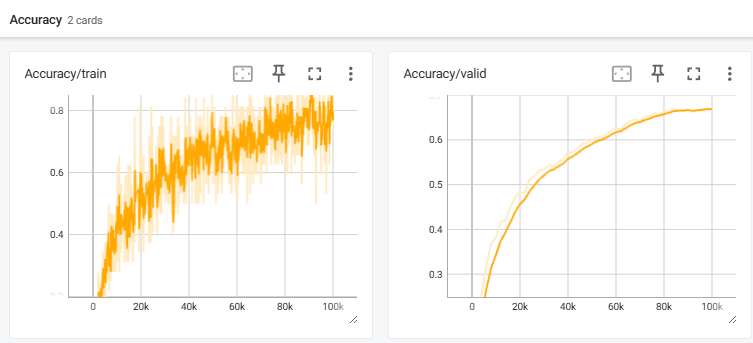

Accuracy

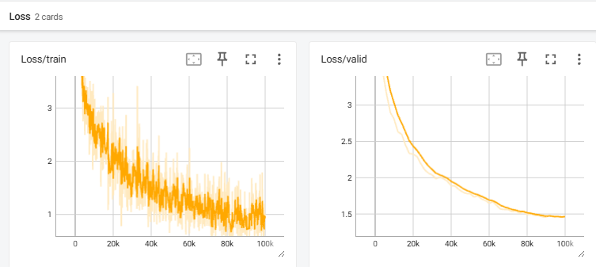

Loss

## Testing Code

We use the best model **model.ckpt** obtained through training to accomplish the classification of speech.

```python
# Load metadata of testing data.
testdata_path = os.path.join(data_dir, "testdata.json")
test_metadata = json.load(open(testdata_path))["utterances"]
test_data =[]
for utterance in test_metadata:
    test_data.append(utterance["feature_path"])

print(f"Length of test_data is {len(test_data)}")
```

```
Length of test_data is 8000
```

```python
### create test_dataset and test_dataloader
class InferenceDataset(Dataset):
    def __init__(self, test_data, data_dir):
        self.data = test_data
        self.path = data_dir

    def __len__(self):
        return len(self.data)

    def __getitem__(self, index):
        feat_path = self.data[index]
        speaker = torch.load(os.path.join(self.path, feat_path), weights_only=True)

        return feat_path, speaker

test_dataset = InferenceDataset(test_data, data_dir)

test_loader = DataLoader(
        test_dataset,
        batch_size=1,
        shuffle=False,
        drop_last=False,
        num_workers=0,
        collate_fn=inference_collate_batch,
    )
```

```python
# predict
def predict(test_loader, model, device):
    model.eval() # Set your model to evaluation mode.
    labels = []
    with torch.no_grad():
        for path, feature in test_loader:
            feature = feature.to(device)
            test_pred = model(feature)
            # Find the maximum in test_pred
            test_label = np.argmax(test_pred.detach().cpu().numpy(), axis=1)
            labels.append(test_label)
        labels = np.concatenate(labels, axis=0)
        return labels

model = Classifier(n_spks=speaker_num).to(device)
model.load_state_dict(torch.load(config['save_path'], weights_only=True))
preds = predict(test_loader, model, device)
```

### Saving Results

```python
def save_pred(preds, file):
    with open(file, 'w') as fp:
        writer = csv.writer(fp)
        writer.writerow(['id', 'tested_results'])
        for i, p in enumerate(preds):
            writer.writerow([i, p])

save_pred(preds, './Voxceleb2/pred.csv')
display_results = pd.read_csv('./Voxceleb2/pred.csv')

print("Prediction Results")
print(display_results)
```

```
Prediction Results
        id  tested_results
0        0             334
1        1             407
2        2             330
3        3             460
4        4             406
...    ...             ...
7995  7995             162
7996  7996             413
7997  7997              69
7998  7998             174
7999  7999             262

[8000 rows x 2 columns]
```

Back to top